# Cross-Border Transmission Regimes: ANOVA and Cluster Analysis

Statistical validation of the transmission-regime taxonomy in the LEEDS MRIO-SFC model

Author

Oriol Vallès Codina

Published

October 2, 2026

[output not shown]

### 0.0.1 Excluded-construction render

> This is a second render of `qmd/cross_border_analysis.qmd`, on **12 scenarios**: the two Construction scenarios — **Sc5 Cnst-FD** and **Sc14 Cnst-Int** — are withheld from `sc_meta`, the scenario registry, and every chunk downstream of it filters with it. The numbers, tables and dendrograms below are computed on those 12 and on nothing else.

> **Why they are withheld.** They are the two largest divergences in the scenario set, by roughly an order of magnitude, and they are also the only two scenarios the four- and five-regime taxonomies disagree about. Both properties matter. Left in, they set the scale on which the remaining twelve are merged, so the twelve are assigned under the influence of two points that belong to no group of their own; and the partition that results can then be read as evidence about the regime count when it is mostly evidence about the two outliers.

> **The exclusion is the point, not a robustness check.** Withholding them is the settled resolution of the four-versus-five question (audit Correction 5; `ai_context/04_OPEN_QUESTIONS.md` error 3). Held out, the two candidate taxonomies are the *same* partition on the twelve: `identical(regime4, regime5)` is **TRUE** in this render. The whole of the disagreement between them is carried by the two scenarios that are no longer here. What is left to ask of the data is whether it supports the four-group partition they agree on, and §“The exclusion, and what it changes” answers that by running both specifications side by side.

> The all-fourteen counterpart of this document is `output/html/cross_border_analysis.html`; the two differ in nothing but the registry.

# 1 Introduction

This report validates the transmission-regime taxonomy used in the LEEDS MRIO-SFC model analysis of circular economy (CE) transition scenarios, on the twelve scenarios that remain once the two Construction scenarios are withheld. The scenarios it classifies into groups are these:

| Regime | Scenarios | Mechanism |
| --- | --- | --- |
| **Production Leakage** | Sc1, 4, 9 | Secondary sector’s higher import content unintentionally raises RoW intermediate exports |
| **Symmetric Contraction** | Sc3, 6, 7, 8, 11, 12 | Both regions contract proportionally; EU restructuring generates no directional asymmetry |
| **Competitive Displacement** | Sc10 | Secondary metals’ lower A-matrix row-sum frees EU intermediate resources; *only scenario* with true sign reversal (EU↑, RoW↓) |
| **Fossil Import Collapse** | Sc2, 13 | EU fossil import reduction collapses RoW hydrocarbon export revenues; RoW fiscal space deteriorates |

# 2 Data and Variables

Extended variable set used in the analysis

| Label | Full name | Category | Unit | In shock table |
| --- | --- | --- | --- | --- |
| emis | Annual CO2 Emissions | Ecological | 10t CO2 eq. | TRUE |
| land | Land Used | Ecological | ha | TRUE |
| mat | Extraction of Matter | Ecological | 10Mt | TRUE |
| rec | Recycled Matter | Ecological | 10Mt | TRUE |
| wa | Waste | Ecological | 10Mt | TRUE |
| water | Water Used | Ecological | l | TRUE |
| x_mat | Production of Material Goods | Ecological | 10Mt | TRUE |
| c | Total Real Consumption | Households | 10B.EUR | TRUE |
| shp | Profit Share of Disposable Income | Households |  | TRUE |
| shw | Wage Share of Disposable Income | Households |  | TRUE |
| v | Net Household Wealth | Households | 10B.EUR | TRUE |
| b_s | Government Debt | govt.central.bank | 10B EUR | TRUE |
| gdef | Government Deficit | govt.central.bank | 10B.EUR | TRUE |
| id | Real Investment in Fixed Capital | investment | 10B.EUR | TRUE |
| k | Fixed Capital Stock | investment | 10B.EUR | TRUE |
| lf | Corporate Demand for Bank Loans | investment | 10B.EUR | TRUE |
| n | Employment | labor.market | 10M p. | TRUE |
| nf | Female Employment | labor.market | 10M p. | TRUE |
| lh | Household Demand for Personal Loans | portfolio.choices | 10B.EUR | TRUE |
| go | Gross Output | production | 10B.EUR | TRUE |
| va | Value Added | production | 10B.EUR | TRUE |
| co2_cum | CO2 Concentration | Ecological | 10t CO2 eq. | FALSE |
| ineq | Functional Inequality | Households |  | FALSE |
| yd | Disposable Income | Households | 10B.EUR | FALSE |
| ydc | Capitalist Disposable Income | Households | 10B.EUR | FALSE |
| ydw | Worker Disposable Income | Households | 10B.EUR | FALSE |
| imp | Real Final Imports | balance.of.payments | 10B.EUR | FALSE |
| rex | Real Final Exports | balance.of.payments | 10B.EUR | FALSE |
| debt_gdp | Debt to GDP Ratio | govt.central.bank |  | FALSE |
| t | Tax Payments | govt.central.bank | 10B.EUR | FALSE |
| wb | Wage Bill | labor.market | 10B.EUR | FALSE |
| f_f | Corporate Profit | production | 10B.EUR | FALSE |
| fd | Final Demand in Real Terms | production | 10B.EUR | FALSE |
| y | Nominal Output | production | 10B.EUR | FALSE |

The 23 core variables from the shock-summary tables are supplemented with 14 additional documented aggregates: disposable income decomposition (yd, ydw, ydc), functional inequality (ineq), the debt-to-GDP ratio, wage bill, corporate profit, cumulative CO₂ concentration, trade flows (imp, rex), fiscal flows (g, t), and output aggregates (y, fd). Variables with zero variance in their Z1−Z2 divergence are excluded from clustering (accounting identities such as current account and trade balance cancel bilaterally).

# 3 EU−RoW Divergence Heatmap

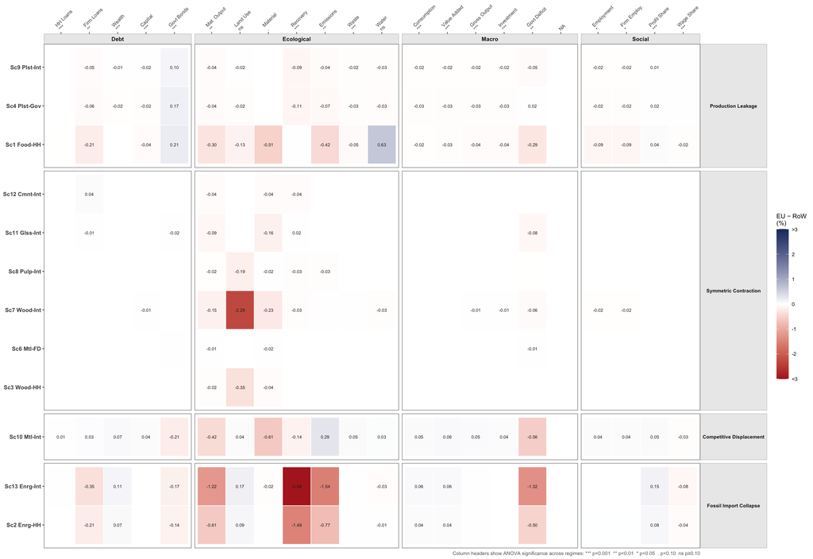

EU−RoW long-term divergence (Z1 − Z2, % deviation from baseline). Blue = EU effect exceeds RoW; red = RoW effect exceeds EU. Colour scale capped at ±3% to prevent fiscal extreme values from compressing the palette. Scenarios grouped by transmission regime (rows); variable categories (columns).

**Production Leakage** (Sc1, Sc4, Sc9) shows moderate but consistent red in ecological columns, indicating that EU’s ecological gains exceed RoW’s — but less dramatically than the fossil scenarios. The leakage occurs through intermediate import channels: secondary-sector production in the EU draws more on RoW inputs, partially diffusing the ecological gain outward.

# 4 ANOVA: Are Regime Divergences Statistically Different?

One-way ANOVA tests whether mean EU−RoW divergence differs across the 4 transmission regimes (H₀: all group means equal; df_between = 3, df_within = 8). Effect size η² = SS_between / SS_total is analogous to R². The OLS regression fits Z2 ~ Z1 across the 12 scenarios per variable, where slope > 0 indicates co-movement and slope < 0 indicates asymmetric sign reversal. Both analyses use long-term (t+20 periods) percentage deviations from baseline.

Combined ANOVA and OLS statistics for all variables, sorted by η². ANOVA: are regime group means different? OLS: do Z1 and Z2 co-move? Sig. codes: *** p<0.001, ** p<0.01, * p<0.05, . p<0.10, ns p≥0.10.

| Variable | Category | ANOVA (divergence ~ regime) F | ANOVA (divergence ~ regime) p (ANOVA) | ANOVA (divergence ~ regime) η² | OLS (Z2 ~ Z1, n=12) Slope (Z2~Z1) | OLS (Z2 ~ Z1, n=12) R² |
| --- | --- | --- | --- | --- | --- | --- |
| fd | production | 92.72 | 1.5e-06 | 0.972 *** | -0.388 *** | 0.979 |
| debt_gdp | govt.central.bank | 86.96 | 1.9e-06 | 0.97 *** | -0.254 *** | 0.922 |
| t | govt.central.bank | 76.65 | 3.1e-06 | 0.966 *** | -0.288 *** | 0.976 |
| b_s | govt.central.bank | 76.54 | 3.1e-06 | 0.966 *** | -0.241 *** | 0.908 |
| c | Households | 74.77 | 3.4e-06 | 0.966 *** | -0.298 *** | 0.988 |
| lh | portfolio.choices | 74.66 | 3.4e-06 | 0.966 *** | -0.169 ** | 0.555 |
| imp | balance.of.payments | 70.42 | 4.3e-06 | 0.964 *** | -0.383 *** | 0.766 |
| rex | balance.of.payments | 70.42 | 4.3e-06 | 0.964 *** | -2.002 *** | 0.766 |
| va | production | 65.54 | 5.7e-06 | 0.961 *** | -0.304 *** | 0.963 |
| wb | labor.market | 64.76 | 5.9e-06 | 0.96 *** | -0.177 . | 0.285 |
| ydw | Households | 64.76 | 5.9e-06 | 0.96 *** | -0.177 . | 0.285 |
| yd | Households | 57.69 | 9.2e-06 | 0.956 *** | -0.259 *** | 0.991 |
| v | Households | 51.36 | 1.4e-05 | 0.951 *** | -0.174 *** | 0.891 |
| y | production | 46.36 | 2.1e-05 | 0.946 *** | -0.212 * | 0.360 |
| go | production | 35.71 | 5.6e-05 | 0.931 *** | -0.277 * | 0.413 |
| wa | Ecological | 29.78 | 1.1e-04 | 0.918 *** | -0.248 * | 0.389 |
| co2_cum | Ecological | 26.52 | 1.7e-04 | 0.909 *** | 0.014 . | 0.312 |
| ydc | Households | 26.04 | 1.8e-04 | 0.907 *** | -0.124 *** | 0.820 |
| id | investment | 24.33 | 2.2e-04 | 0.901 *** | -0.269 * | 0.399 |
| f_f | production | 22.63 | 2.9e-04 | 0.895 *** | -0.134 *** | 0.850 |
| k | investment | 20.69 | 4.0e-04 | 0.886 *** | -0.25 * | 0.353 |
| rec | Ecological | 19.31 | 5.1e-04 | 0.879 *** | 0.037 *** | 0.970 |
| ineq | Households | 17.82 | 6.7e-04 | 0.87 *** | -0.036 ** | 0.583 |
| shp | Households | 17.81 | 6.7e-04 | 0.87 *** | -0.037 ** | 0.583 |
| shw | Households | 17.80 | 6.7e-04 | 0.87 *** | -0.036 ** | 0.583 |
| emis | Ecological | 15.76 | 1.0e-03 | 0.855 ** | 0.015 . | 0.330 |
| lf | investment | 13.13 | 1.9e-03 | 0.831 ** | 0.028 . | 0.328 |
| x_mat | Ecological | 12.78 | 2.0e-03 | 0.827 ** | 0.055 * | 0.419 |
| gdef | govt.central.bank | 9.02 | 6.0e-03 | 0.772 ** | 1.171 *** | 0.981 |
| n | labor.market | 5.02 | 3.0e-02 | 0.653 * | -0.151 * | 0.341 |
| nf | labor.market | 5.02 | 3.0e-02 | 0.653 * | -0.151 * | 0.341 |
| mat | Ecological | 3.33 | 7.7e-02 | 0.555 . | 0.134 ** | 0.575 |
| water | Ecological | 0.81 | 5.2e-01 | 0.233 ns | 0.072 *** | 0.866 |
| land | Ecological | 0.50 | 6.9e-01 | 0.158 ns | 0.003 ns | 0.061 |

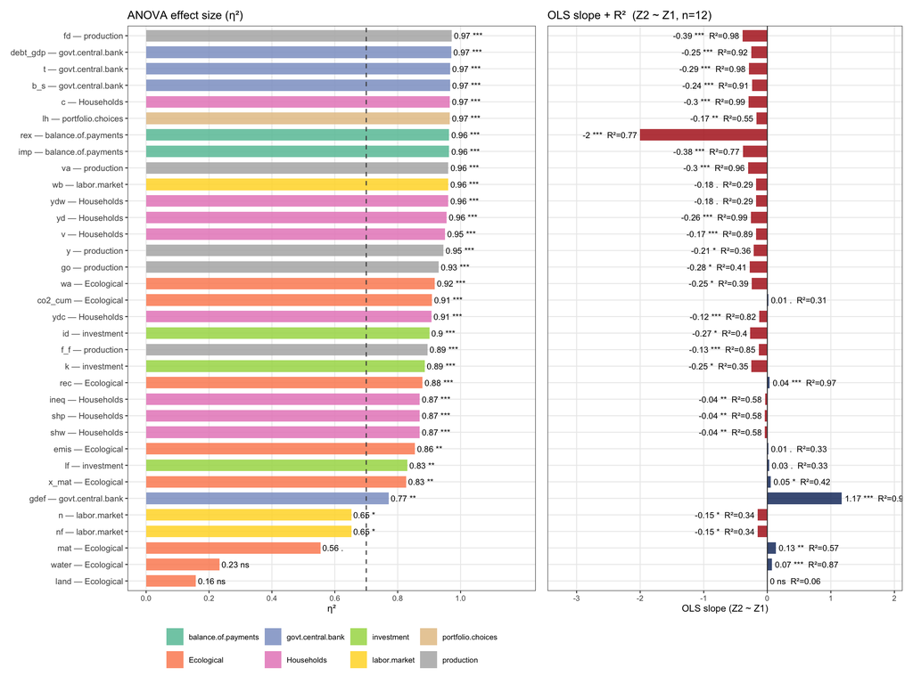

Left panel: η² (ANOVA effect size) per variable, coloured by category. Right panel: OLS slope (Z2 ~ Z1) with R² label. Both sorted by η². Dashed lines at η²=0.70 and slope=0. Stars = significance level.

# 5 Hierarchical Clustering: Two Coordinate Spaces

## 5.1 Why the coordinate space matters

The five transmission regimes are defined by a *pair* of regional signs. “Competitive Displacement” is the case where the EU expands **while** the Rest of World contracts; “Symmetric Contraction” is the case where both move the same way. Those are statements about the joint pattern of `Z1` and `Z2`, not about their difference.

This has a direct consequence for how the scenarios may be clustered. A divergence of +0.5 is produced equally by (`Z1` +0.4, `Z2` −0.1) — a genuine sign reversal — and by (`Z1` +0.6, `Z2` +0.1), where both regions expand. Those are two different regimes with identical coordinates. **Differencing removes the information the regime taxonomy is defined by**, and no clustering algorithm can recover a distinction the coordinate transform has already destroyed.

Two spaces are therefore used throughout what follows, and they answer different questions:

| space | vector per scenario | what it can test |
| --- | --- | --- |
| **Divergence** `Z1 − Z2` | one value per variable | cross-border *asymmetry* — how unequally a shock lands |
| **Joint** `(Z1, Z2)` | two values per variable, standardised separately | the full two-region *signature*, including sign patterns |

The divergence space additionally destroys the current account and trade balance outright: `cab` and `tb` are bilateral accounting identities that cancel exactly between the regions, so their divergence is identically zero and they are dropped. In the joint space both survive.

## 5.2 Clustering Procedure

Scenarios are clustered on the 37 documented aggregates, in both spaces: 72 columns in the joint space and 34 in the divergence space. The difference is the three variables whose *divergence* has zero variance and is therefore dropped — `cab` and `tb`, which cancel bilaterally as accounting identities, and `g`, which is exogenous and identical across scenarios. All three carry information in the joint space and are retained there. Variables are standardised before clustering so that high-variance fiscal variables do not dominate the distance metric.

**Algorithm:** Ward’s D2 linkage with Euclidean distance. Ward’s method minimises within-cluster total variance at each merge step, producing compact, similarly-sized clusters appropriate for the small sample (n=12).

## 5.3 Dendrogram

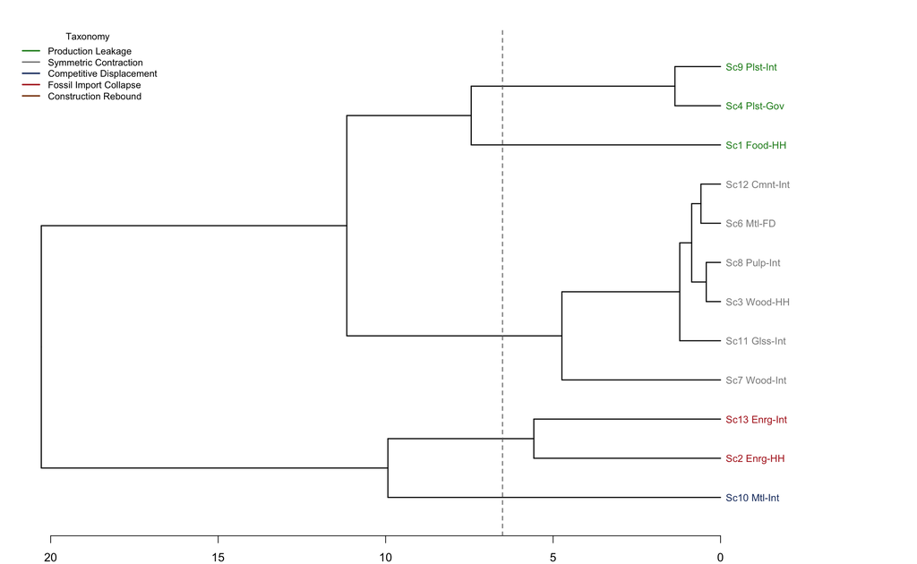

**Discussion.** With the construction pair withheld the hierarchy has no dominant outlier, and the splits come out in the order the taxonomy predicts:

1. **First split** (height 20.281 in the divergence space) separates the core nine — Sc1, Sc3, Sc4, Sc6, Sc7, Sc8, Sc9, Sc11, Sc12 — from the three high-leverage scenarios Sc2, Sc10 and Sc13. On the fourteen this first split isolates Sc5 alone; that the same split now separates a group of three is the clearest single effect of the exclusion.
2. **Second split** (height 11.159) separates inside the core: {Sc1, Sc4, Sc9} from {Sc3, Sc6, Sc7, Sc8, Sc11, Sc12}. Those are Production Leakage and Symmetric Contraction, the taxonomy’s two largest regimes, recovered as the two branches.
3. **Third split** (height 9.931) produces k=4 by separating {Sc2, Sc13} from {Sc10} — Fossil Import Collapse and Competitive Displacement. The k=4 cut is therefore exactly the four-regime partition, in this space and in the joint space alike.

**Sc10 (Competitive Displacement) remains the weakest element.** It is a singleton at k=4 and stays so at k=5 and k=6, rather than merging into the Fossil group as it does on the fourteen. Its membership is nonetheless the one the four-group taxonomy asserts, and the k=4 partition matches that taxonomy exactly — so the honest reading is that the twelve place Sc10 on its own, which is what the taxonomy claims but is a claim from a single scenario. This is taken up in “On ‘Competitive Displacement’ as a Standalone Regime” below.

## 5.4 How Many Clusters? Silhouette Against a Permutation Null

Three of the four criteria previously reported here — the gap statistic and the AIC and BIC of a Gaussian mixture model — are not usable on this data, and the reason is structural rather than incidental. With 34 variables and 12 scenarios, p/n ≈ 2.8.

- The **gap statistic** compares observed within-cluster dispersion against a uniform reference distribution over the bounding box of the data. In 34 dimensions containing 12 points that reference is dispersed almost everywhere, the comparison degenerates, and the 1-SE rule fires at the first k it tests.
- **Gaussian mixture models** estimate a mean vector and a covariance structure per component. With p > n the likelihood is not identified, and the reported optimum is the search ceiling rather than an estimate.

They are replaced here by a **permutation null**, which makes no distributional assumption: each variable’s column is permuted independently, destroying the association between variables within a scenario while preserving every variable’s marginal distribution exactly. The question it answers is the one that matters — is the observed cluster separation greater than what exchangeable data of the same shape produces?

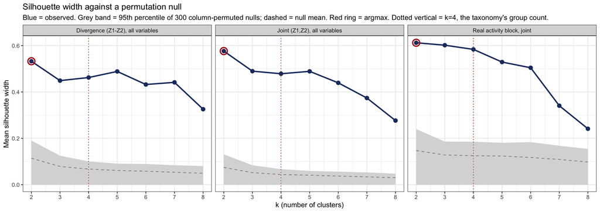

**Discussion.** Two results, and they must be kept apart.

**There is cluster structure, and it is unambiguous.** Across 300 permutations the observed silhouette is never matched at any k from 2 to 8, in any of the three variable sets — not one of the 300 draws matched it, so the permutation p-value is below the resolution of the test, 0.0033 (0 exceedances out of 300) — with observed values 2.5 to 11.9 times the null mean. The earlier reading — that a gap statistic and a BIC of k=1 indicated no structure — was wrong: those criteria are uninformative here, not negative.

**The number of clusters is still not identified.** On the pooled variable set the silhouette is highest at k=2 (0.576 in the joint space) and falls from there to a local bump at k=5 (0.489) that is below the k=2 value and is not an interior maximum. That is the expected behaviour of a relative criterion at n=12, and it is what the fourteen do too: withholding the construction pair does not make the number of clusters identifiable, it makes the partition at a given k recoverable. Reported this way round deliberately, because a reader who took the exact k=4 recovery for a selected k would be reading a choice into the data that is not there.

The consequence for this analysis is methodological. Because k is not identified, the four-group taxonomy cannot be *discovered* from these data. It can, however, be **tested**: it is a partition specified in advance on mechanistic grounds, and the question is whether clustering recovers it. That question is answered with the adjusted Rand index (ARI), which counts the scenario pairs two partitions agree about, corrected for chance — 0 is chance-level agreement, 1 is identity.

## 5.5 Which Variables Carry the Regime Signal?

The regimes are named for transmission mechanisms — Production *Leakage*, Competitive *Displacement*, Fossil *Import Collapse*, Symmetric *Contraction*, Construction *Rebound*. None names an ecological outcome. If that naming is more than rhetorical, the regime signal should sit in the variables through which transmission runs, and not in the ecological satellite accounts.

That is testable. Each of the six blocks defined above is clustered on its own, in both spaces, and its partition at the taxonomy’s own k (4) scored against the taxonomy.

Silhouette schedule by variable block and coordinate space. Final column: adjusted Rand index of that block's k=4 partition against the taxonomy under test.

| Space | Block | p | best k | silhouette, k = 2 .. 8 | ARI @ k=4 |
| --- | --- | --- | --- | --- | --- |
| Divergence | Real activity | 6 | 4 | 0.580 0.596 0.619 0.581 0.493 0.357 0.272 | 1.000 |
| Divergence | Finance & wealth | 5 | 2 | 0.589 0.521 0.530 0.527 0.465 0.291 0.193 | 1.000 |
| Divergence | All variables | 34 | 2 | 0.532 0.449 0.462 0.488 0.432 0.441 0.326 | 1.000 |
| Divergence | Fiscal | 4 | 3 | 0.661 0.693 0.663 0.578 0.497 0.436 0.215 | 0.926 |
| Divergence | External | 2 | 3 | 0.728 0.761 0.749 0.667 0.553 0.392 0.409 | 0.926 |
| Divergence | Labour & distribution | 9 | 5 | 0.543 0.540 0.516 0.562 0.529 0.395 0.270 | 0.926 |
| Divergence | Ecological | 8 | 3 | 0.499 0.514 0.490 0.508 0.448 0.355 0.291 | 0.553 |
| Joint | Real activity | 12 | 2 | 0.612 0.602 0.584 0.529 0.504 0.341 0.241 | 1.000 |
| Joint | Finance & wealth | 10 | 2 | 0.622 0.559 0.529 0.486 0.476 0.306 0.210 | 1.000 |
| Joint | All variables | 72 | 2 | 0.576 0.490 0.479 0.489 0.439 0.374 0.277 | 1.000 |
| Joint | Fiscal | 8 | 3 | 0.709 0.788 0.690 0.599 0.531 0.448 0.312 | 0.926 |
| Joint | External | 8 | 3 | 0.691 0.693 0.632 0.609 0.469 0.419 0.298 | 0.926 |
| Joint | Labour & distribution | 18 | 2 | 0.584 0.542 0.527 0.575 0.528 0.399 0.271 | 0.926 |
| Joint | Ecological | 16 | 3 | 0.448 0.485 0.470 0.366 0.357 0.301 0.225 | 0.553 |

**Discussion.** The blocks differ enormously in what they carry, and the pattern is systematic.

**Three blocks now recover the taxonomy exactly, in both spaces.** Real activity, Finance & wealth and the pooled all-variable set each reach ARI 1.000 at k=4, in the divergence space and the joint space alike; Fiscal, External and Labour & distribution follow at 0.926; and only the Ecological block falls below that. Six of the seven blocks therefore agree with the taxonomy at 0.926 or better, and the two coordinate spaces agree with each other in every row.

**The Ecological block still carries the least regime information**: ARI 0.553 in the divergence space and 0.553 in the joint space, the two lowest figures in the table on this registry too. This is the substantive finding of the section, not a nuisance result, and the exclusion strengthens rather than weakens it: removing the two scenarios that dominated the distance matrix raises every other block to 0.926 and leaves this one at 0.553. Transmission regimes are constituted in the trade and real-activity structure; **ecological outcomes are consequences of those regimes rather than definitions of them**. The regime taxonomy and the ecological results are therefore logically independent, which is what allows the paper to report an ecological trilemma *within* a regime rather than confounding the two.

**The previously published specification — all variables, divergence space — is now one of the best cells in the table**, where on the fourteen it was the second-worst (ARI 0.565). On the twelve it reaches 1.000, equal to the joint-space figure. It pooled a strong real-activity and external signal with an ecological block that carries none, and differencing did not cost it the partition — the cost was the two scenarios the divergence space was most sensitive to.

## 5.6 Does the Data Recover the Four-Group Taxonomy?

Adjusted Rand index between the data partition and the taxonomy of 4 groups, by k and coordinate space, on the full variable set of 12 scenarios.

| Space | k=2 | k=3 | k=4 | k=5 | k=6 |
| --- | --- | --- | --- | --- | --- |
| Divergence | 0.437 | 0.928 | 1.000 | 0.924 | 0.884 |
| Joint | 0.437 | 0.928 | 1.000 | 0.924 | 0.884 |

On the full variable set in the joint space, the k=4 partition matches the taxonomy at **ARI 1.000**. In the divergence space the same cut reaches only 1.000.

That partition is **stable**: removing each of the 72 columns in turn and re-clustering gives an adjusted Rand index of 1.000 against the full-set partition in 72 of 72 cases. Bootstrap resampling of the variable set (500 replicates, columns drawn with replacement) gives mean ARI 0.974, with 95% of replicates at or above 0.8.

**Two of the 4 regimes are recovered exactly by almost every specification.** Production Leakage {Sc1, Sc4, Sc9} and Symmetric Contraction {Sc3, Sc6, Sc7, Sc8, Sc11, Sc12} — 9 of the 12 scenarios — appear with no errors in 12 of the 12 block-and-space combinations scoring at or above ARI 0.8. They are the solid core of the taxonomy.

**A caution on variable selection.** Drawing random subsets of the pooled divergence variables, silhouette does not land on k=4 reliably, and searching over subsets until one yields 4 clusters would therefore *not* be evidence. Two things distinguish the results above from that failure: the six blocks are a pre-existing economic partition of the variables rather than a search, and the reason for expecting real activity and external flows to carry the signal is stated independently of the result.

## 5.7 Cluster Assignments Across k

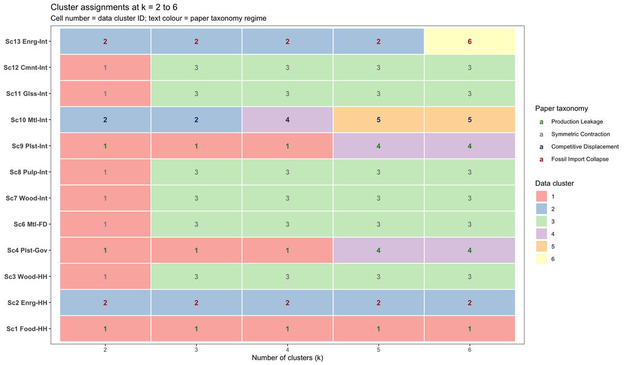

**Discussion.** This panel is the most direct comparison between the data-driven structure and the taxonomy, and with the construction pair withheld the comparison comes out clean:

**The taxonomy appears whole at k=4.** At k=4 the partition is {Sc1, Sc4, Sc9} / {Sc3, Sc6, Sc7, Sc8, Sc11, Sc12} / {Sc2, Sc13} / {Sc10} — Production Leakage, Symmetric Contraction, Fossil Import Collapse and Competitive Displacement, exactly. The same partition appears in both coordinate spaces, which is the second thing that changes: the divergence space and the joint space now agree at every k from 2 to 6, whereas on the fourteen they disagreed sharply (ARI 0.565 against 0.936 at k=5).

**Stable groupings across all k:** Sc3, Sc6, Sc7, Sc8, Sc11, Sc12 (Symmetric Contraction) are in one cluster at every k. Sc1, Sc4, Sc9 (Production Leakage) cohere from k=3, and it is Sc1 that leaves again at k=5 — the same scenario that did so on the fourteen, and for the same reason: Food-HH has the largest household channel, so it is the furthest of the three from the other two.

**The three high-leverage scenarios separate together, then divide.** Sc2, Sc10 and Sc13 hold one cluster at k=2 and k=3; at k=4 they divide into {Sc2, Sc13} and {Sc10}, which is the taxonomy’s Fossil Import Collapse / Competitive Displacement boundary; at k=6 Sc2 and Sc13 part from each other. Nothing here replicates the fourteen’s {Sc10, Sc14} pairing, because Sc14 is not in the data.

## 5.8 Silhouette Plots by k

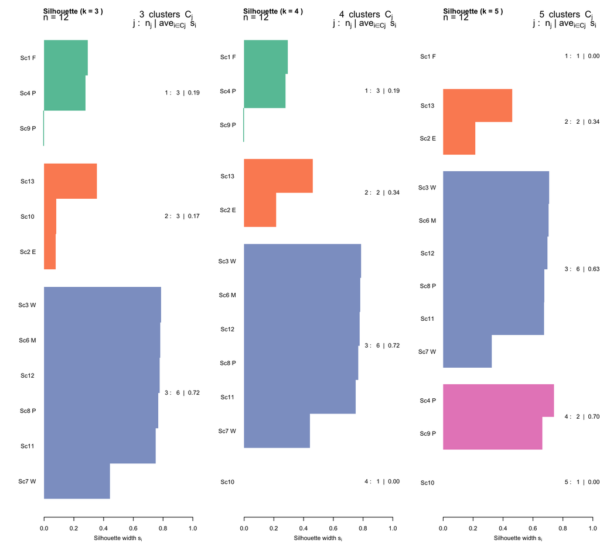

Individual silhouette plots at k=3, 4, and 5. Each bar represents one scenario; bar length = silhouette coefficient (how well the scenario fits its cluster vs the next-best cluster). Negative values indicate potential misclassification.

**Discussion.** Silhouette plots reveal which specific scenarios are most and least confidently classified at each k. Average silhouette width is 0.449 at k=3, 0.462 at k=4 and 0.488 at k=5.

At **k=5**, Sc1 becomes the singleton (0 by definition) and the leakage trio splits into {Sc4, Sc9} (0.66–0.74) and Sc1 alone; Sc10 stays a singleton. The mean is 0.488. Nothing at k=5 corresponds to a fifth regime — with the construction scenarios withheld, the fifth cluster is a split inside Production Leakage.

# 6 Taxonomy Comparison: Paper vs. Data

Comparison of the paper taxonomy (4 regimes) with data-driven cluster assignments at k=3 and k=4.

| Scenario | Paper regime | Data k=3 | Data k=4 |
| --- | --- | --- | --- |
| Sc1 Food-HH | Production Leakage | 1 | 1 |
| Sc2 Enrg-HH | Fossil Import Collapse | 2 | 2 |
| Sc3 Wood-HH | Symmetric Contraction | 3 | 3 |
| Sc4 Plst-Gov | Production Leakage | 1 | 1 |
| Sc6 Mtl-FD | Symmetric Contraction | 3 | 3 |
| Sc7 Wood-Int | Symmetric Contraction | 3 | 3 |
| Sc8 Pulp-Int | Symmetric Contraction | 3 | 3 |
| Sc9 Plst-Int | Production Leakage | 1 | 1 |
| Sc10 Mtl-Int | Competitive Displacement | 2 | 4 |
| Sc11 Glss-Int | Symmetric Contraction | 3 | 3 |
| Sc12 Cmnt-Int | Symmetric Contraction | 3 | 3 |
| Sc13 Enrg-Int | Fossil Import Collapse | 2 | 2 |

# 7 Discussion of Main Findings

## 7.1 The Exclusion, and What It Changes

This section runs the specification twice on the same long-term deviations — once on the fourteen scenarios and once on the twelve this document analyses — so that the effect of the exclusion is measured here rather than quoted from the other render. Nothing is re-tuned between the two runs: the variable blocks, the standardisation, the linkage, the distance and the reference partition are identical, and only the scenario registry differs. The reference partition is the **four**-group one in both runs, because that is the partition both candidate taxonomies agree on and the only one that can be used on both sides of the comparison: the paper’s fifth regime has no members once the construction pair is withheld.

The same specification on two registries. Adjusted Rand index against the four-group partition; the partition column gives the k=4 cut itself, as scenario numbers.

| Registry | Space | p | best k (silhouette) | silhouette at k=4 | ARI at k=4 | ARI at k=5 | partition at k=4 |
| --- | --- | --- | --- | --- | --- | --- | --- |
| all 14 | Joint | 72 | 2 | 0.403 | 0.826 | 0.938 | {1,4,9} {2,10,13,14} {3,6,7,8,11,12} {5} |
| all 14 | Divergence | 34 | 2 | 0.424 | 0.494 | 0.573 | {1} {2,10,13,14} {3,4,6,7,8,9,11,12} {5} |
| these 12 | Joint | 72 | 2 | 0.479 | 1.000 | 0.924 | {1,4,9} {2,13} {3,6,7,8,11,12} {10} |
| these 12 | Divergence | 34 | 2 | 0.462 | 1.000 | 0.924 | {1,4,9} {2,13} {3,6,7,8,11,12} {10} |

**The exclusion makes the taxonomy recoverable, and it makes the two coordinate spaces agree.** On the twelve the k=4 partition is {1,4,9} {2,13} {3,6,7,8,11,12} {10} — Production Leakage, Symmetric Contraction, Fossil Import Collapse and Competitive Displacement, exactly — and the adjusted Rand index against the four-group partition is **1.000 in both spaces**. On the fourteen the same cut reaches 0.826 in the joint space and 0.494 in the divergence space, and the two spaces disagree at every k (at k=5, 0.938 joint against 0.573 divergence, both against the same four-group partition). Two consequences follow, and both are properties of the twelve rather than of the taxonomies:

- **The four regimes of the twelve are the partition the data produce at k=4**, not merely a hypothesis they fail to reject. The two largest regimes are the second split of the hierarchy (see “Dendrogram” above), and the Fossil/Displacement boundary is the third.
- **The divergence space stops being the worse coordinate.** Differencing still destroys the sign information in principle, but on the twelve it does not destroy the *partition*: the two spaces give the identical cut at every k from 2 to 6. The fourteen’s weaker divergence-space figures were therefore not evidence about the coordinate transform — that transform is the one thing the two runs share, so a difference between them cannot be its doing.

**What the exclusion does not do.** It does not make the number of clusters identifiable. The silhouette still peaks at k=2 on the twelve, just as it does on the fourteen, and declines from there; the taxonomy’s k is not selected by any relative criterion in either run, and the test remains a pre-specified one. Nor does the comparison distinguish the two candidate taxonomies from each other: the four- and five-regime hypotheses differ only in how they classify the construction pair, so removing that pair makes them the same partition and leaves nothing for a comparison of them to disagree about. The exclusion settles the count by removing the scenarios the count was in dispute about; it does not adjudicate between the two readings of *those* scenarios, which remain what the all-fourteen render reports.

## 7.2 What the Divergence Space Groups on the Twelve

- **k=2**: the core nine — Sc1, Sc3, Sc4, Sc6, Sc7, Sc8, Sc9, Sc11, Sc12 — against the three high-leverage scenarios Sc2, Sc10, Sc13. The split is by magnitude of transmission, not by mechanism, and it is the same in both spaces.
- **k=3**: {Sc1, Sc4, Sc9} (Production Leakage) and {Sc3, Sc6, Sc7, Sc8, Sc11, Sc12} (Symmetric Contraction) separate from each other inside the core, leaving {Sc2, Sc10, Sc13} still merged.
- **k=4**: {Sc2, Sc10, Sc13} divides into {Sc2, Sc13} (Fossil Import Collapse) and {Sc10} (Competitive Displacement), which is the taxonomy.

So the divergence space’s failure on the fourteen was not a property of the coordinate transform. The transform does destroy the sign information, and a pair of scenarios whose regime is defined by opposite signs (EU up against RoW down) cannot in general be separated from one whose regions move together once the sign is removed. But on these data the asymmetry profile alone separates Sc10 from Sc2 and Sc13, and the failure was caused instead by the two construction scenarios, whose divergences are large enough to dominate the distances on which the other twelve are merged.

## 7.3 On “Competitive Displacement” as a Standalone Regime

The original justification for isolating Sc10 (Mtl-Int) as “Competitive Displacement” rests on a mechanistic distinction: it is the *only* scenario in the set where EU macro variables move *positive* while RoW macro variables move *negative* simultaneously (true sign reversal). In all other high-divergence scenarios, both regions move in the same direction — EU contracts less than RoW, but both contract.

**On the twelve the picture reverses, and it is worth being careful about why.** Sc10 is a singleton at k=4, at k=5 and at k=6 — it never merges into the Fossil group, where on the fourteen it did. The k=4 partition is the four-group taxonomy exactly. Taken at face value that is the strongest support “Competitive Displacement” can get from this method: the cut that reproduces the other three regimes is the same cut that puts Sc10 on its own.

**But it is support from a single scenario**, and that is its whole strength. Sc10 cannot be corroborated from within: its ARI contribution is one cluster containing one member, and a one-member cluster is trivially “recovered” by any cut that puts it anywhere. The evidence that Sc10 is a regime rather than an unusual scenario is the mechanistic one — the sign reversal — and the *reason* it is now on its own is the same as the reason the fourteen’s result was weaker: with Sc5 and Sc14 out, the largest divergences in the set belong to Sc13, and the distance at which Sc10 separates from the fossil pair is small in absolute terms.

**Recommendation:** on this evidence, keep “Competitive Displacement” as a labelled regime only with the count stated as one, and note in the manuscript that its statistical support rests on a single scenario whose separation is by direction and not by magnitude. That is the reading the twelve support, and it is a weaker claim than the four-regime recovery of the other three regimes would suggest on its own.

## 7.4 Why Energy Dominates

One structural feature of the model explains the extreme salience of the energy (Sc13) scenario, which is the largest divergence in this render:

**Energy (Sc13):** The intermediate energy channel is simultaneously the *largest* channel in the scenario set (14.8 billion EUR) and the *most intensity-differential* material pair (emission intensity ratio 3.3:1 between secondary and primary energy). These two factors — scale and intensity differential — are multiplicative in the ΔM formula, making Sc13 the highest-leverage ecological scenario by construction. The cross-border fiscal effect is equally extreme because EU fossil fuel imports represent a direct bilateral income transfer: reducing them by ρ=0.2 removes a substantial, concentrated revenue stream from RoW hydrocarbon exporters without any compensating income source within the model’s RoW structure.

**Construction (Sc5).** The construction channel operates through *investment*, not consumption or intermediate demand, and its investment base (88.7 billion EUR, 66.7% of total construction demand) is the largest single channel in the scenario set; that, rather than the size of ρ, is why Sc5 generated the largest absolute divergences on the fourteen, including the emissions rebound of +5.14. It is withheld from this render, and the two paragraphs on the construction channel and on the validity of the “Construction Rebound” label are consequently absent: they are claims about data this render does not contain. They are carried in `output/html/cross_border_analysis.html`, which is where the construction scenarios are analysed.